# Part I - ( Loan Data from prosper Exploration)

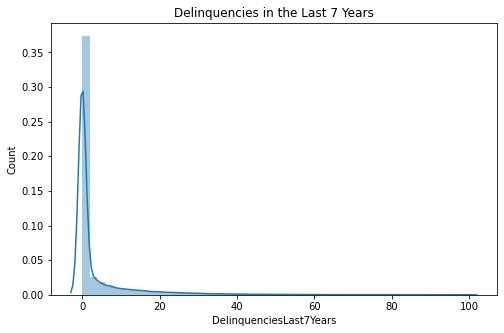

```python
# to check for distribution of Delinquencies in the Last 7 Years
plt.figure(figsize = [8,5])
sns.distplot(df_new_loan.DelinquenciesLast7Years)
plt.title('Delinquencies in the Last 7 Years')
plt.xlabel('DelinquenciesLast7Years')
plt.ylabel('Count');
```

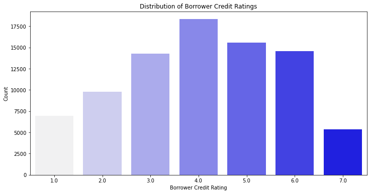

```python
#to show distribution of borrower credit ratings
plt.figure(figsize = [12, 6])
sns.countplot(data = df_new_loan, x = 'ProsperRating (numeric)', palette ="light:b")
plt.xlabel('Borrower Credit Rating')
plt.ylabel('Count')
plt.title('Distribution of Borrower Credit Ratings');
```

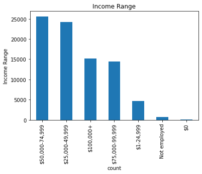

```python
#to check the income range of borrowers

def plot_scatter(a,b,c):
    plt.scatterplot(x=a, y=b, data=c)
    plt.figsize=(12,12)
    plt.fontsize = 12
df_new_loan['IncomeRange'].value_counts().plot(kind='bar')
plt.title('Income Range')
plt.xlabel('count')
plt.ylabel('Income Range');
```

#### We find in this visualization the income range of those that borrowed loan. The visualization shows that most borrowers have an income earning of about $74,999-$49, 999

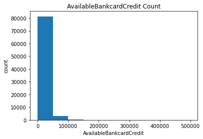

```python
#to find the count of borrowers with Bank card credit
plt.hist(data = df_new_loan, x = 'AvailableBankcardCredit',)
plt.title('AvailableBankcardCredit Count')
plt.xlabel('AvailableBankcardCredit')
plt.ylabel('count');
```

## Bivariate Exploration

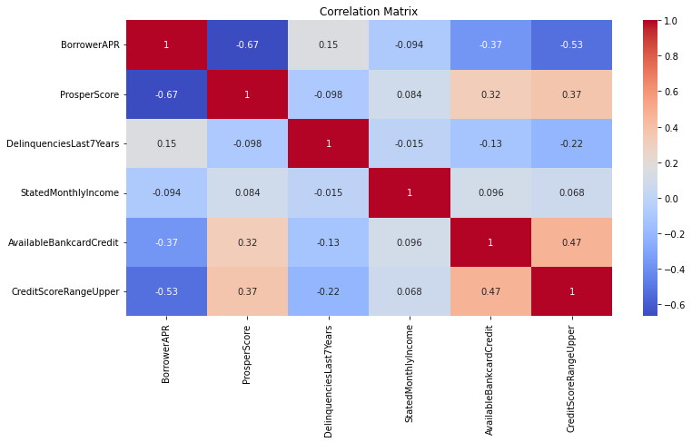

```python
 #to find correlation between attributes
numerical_variables = ['BorrowerAPR', 'ProsperScore', 'DelinquenciesLast7Years',
            'StatedMonthlyIncome', 'AvailableBankcardCredit', 'CreditScoreRangeUpper']

fig = plt.figure(figsize =(12, 6))
sns.heatmap(df_new_loan[numerical_variables].corr(), annot= True, cmap ='coolwarm')
plt.title('Correlation Matrix')
plt.show()
```

#### The Correlation Plot shows generally that there are not exactly any strong positive relationships between any of the paired variables. But the BorrowerAPR and ProsperScore are negatively correlated because borrowers with lower score are more likely to pay higher APR. Also, higher CreditScore means the borrowers can be trusted more, and so it got a lower APR. The correlation also shows that AvailableBankcardCredit has better creditscore.

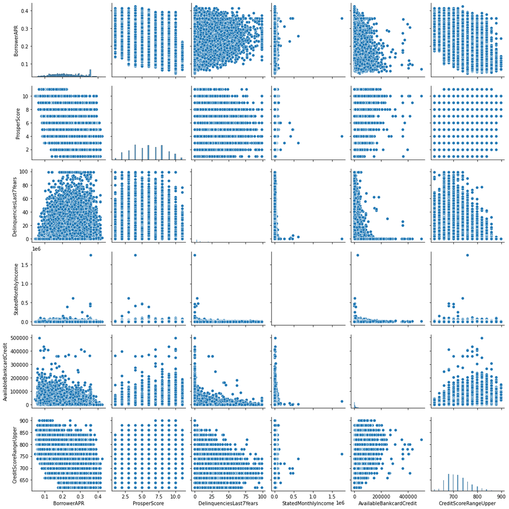

```python
numerical_variables = ['BorrowerAPR', 'ProsperScore', 'DelinquenciesLast7Years',
            'StatedMonthlyIncome', 'AvailableBankcardCredit', 'CreditScoreRangeUpper']
sns.pairplot(data= df_new_loan, vars = numerical_variables);
```

#### The Matrix Plot shows the relationship between the variables, just as the correlation plot, we can determine which pair has negative or positive relationships from analyzing the pattern in each scatter plots. ProsperScore seems to be more related to BorrowerAPR compare to other variables.

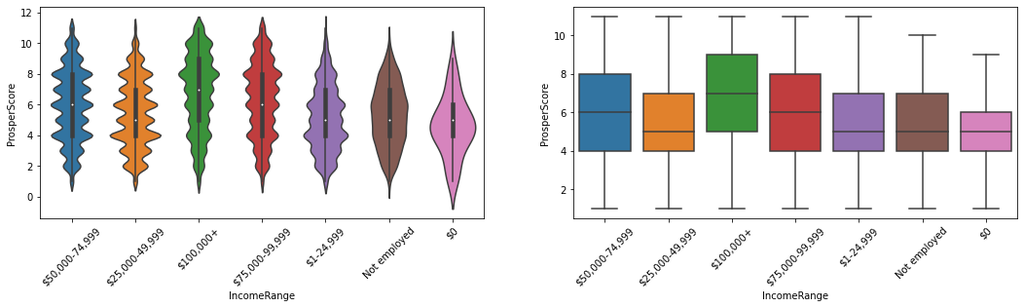

```python
Func_plot(df_new_loan,"IncomeRange", "ProsperScore")
```

### Talk about some of the relationships you observed in this part of the investigation. How did the feature(s) of interest vary with other features in the dataset?

> The correlation and matrix plots are really helpful to check for all the possibles variables that are related to BorrowerAPR. The visualization shows that out of all variables, ProsperScore has stronger relationship with BorrowerAPR (negative correlated). Using the Bivariate Exploration compared to Univariate Exploration,it helps to examine and gain insights more about the BorrowerAPR.

## Multivariate Exploration

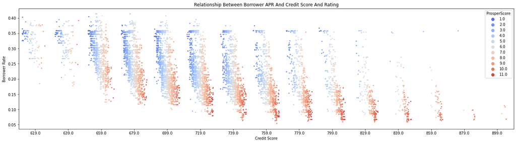

```python
# this plot is memory intensive, create a smaller sample of data to use it
df_sample=df_new_loan.sample(10000, random_state=42)

#set plot dimensions
plt.figure(figsize =(24, 6))
sns.stripplot(data=df_sample, x = 'CreditScoreRangeUpper', y = 'BorrowerAPR', hue ='ProsperScore',
             jitter=0.35, dodge=True, size=3, palette='coolwarm')

plt.title('Relationship Between Borrower APR And Credit Score And Rating')
plt.xlabel('Credit Score',)
plt.ylabel('Borrower Rate');
```

## Conclusions

> Generally, all visualizations made from univariate exploration to bivariate exploration to multivariate exploration, most of the variables are found to be negatively correlated to BorrowerAPR, whereas ProsperScore gives the strongest negative relationship.